# Supervised Learning Project

## Data Description

The csv contains data on 5000 customers. The data include customer demographic information (age, income, etc.), the customer's relationship with the bank (mortgage, securities account, etc.), and the customer response to the last personal loan campaign (Personal Loan). Among these 5000 customers, only 480 (= 9.6%) accepted the personal loan that was offered to them in the earlier campaign.

## Domain

Banking

## Context

This case is about a bank (Thera Bank) whose management wants to explore ways of converting its liability customers to personal loan customers (while retaining them as depositors). A campaign that the bank ran last year for liability customers showed a healthy conversion rate of over 9% success. This has encouraged the retail marketing department to devise campaigns with better target marketing to increase the success ratio with minimal budget.

## Attribute Information

ID: Customer ID

Age: Customer's age in completed years

Experience : #years of professional experience

Income: Annual income of the customer (thousand dollars)

ZIP Code: Home Address ZIP code.

Family: Family size of the customer

CCAvg: Avg. spending on credit cards per month (thousand dollars)

Education: Education Level. 1: Undergrad; 2: Graduate; 3: Advanced/Professional

Mortgage: Value of house mortgage if any. (thousand dollars)

Personal Loan: Did this customer accept the personal loan offered in the last campaign?

Securities Account: Does the customer have a securities account with the bank?

CD Account: Does the customer have a certificate of deposit (CD) account with the bank?

Online: Does the customer use internet banking facilities?

Credit card: Does the customer use a credit card issued by bank

## Objective

To design the best model and target a bank's customers in offering them personal loans. Our modelling shall be based on the data available from a similar campaign run by the bank last year.

We experiment a few classification models such as Logistic Regression, Naive-Bayes, K Nearest Neighbors & Support Vector Machines and select the one that provides the best accuracy for our dataset.

### 1. Import necessary libraries and read data

```python
# import libraries for data analysis & manipulation,array handling and data visualization
import pandas as pd                   # for data analysis & manipulation
import numpy as np                    # array handling
import matplotlib.pyplot as plt       # visualization library
%matplotlib inline
import seaborn as sns                 # visualization library
```

```python
#Reading data into a pandas dataframe
df = pd.read_csv('C:\\Users\\Srikanta\\Desktop\\Great Learning\\Python Files\\Week 12 Supervised Learning Project\\Bank_Personal_Loan_Modelling.csv')

#Check if the dataset is loaded correctly into a dataframe
df.head()
```

|  | ID | Age | Experience | Income | ZIP Code | Family | CCAvg | Education | Mortgage | Personal Loan | Securities Account | CD Account | Online | CreditCard |
| --- | --- | --- | --- | --- | --- | --- | --- | --- | --- | --- | --- | --- | --- | --- |
| 0 | 1 | 25 | 1 | 49 | 91107 | 4 | 1.6 | 1 | 0 | 0 | 1 | 0 | 0 | 0 |
| 1 | 2 | 45 | 19 | 34 | 90089 | 3 | 1.5 | 1 | 0 | 0 | 1 | 0 | 0 | 0 |
| 2 | 3 | 39 | 15 | 11 | 94720 | 1 | 1.0 | 1 | 0 | 0 | 0 | 0 | 0 | 0 |
| 3 | 4 | 35 | 9 | 100 | 94112 | 1 | 2.7 | 2 | 0 | 0 | 0 | 0 | 0 | 0 |
| 4 | 5 | 35 | 8 | 45 | 91330 | 4 | 1.0 | 2 | 0 | 0 | 0 | 0 | 0 | 1 |

```python
#Check the number of rows and columns in our data
df.shape
```

```
(5000, 14)
```

Dataset has 5000 observations and 14 columns(of which 1 variable is the target variable)

```python
#Learn the data types of different attributes and check for null values
df.info()
```

```
<class 'pandas.core.frame.DataFrame'>
RangeIndex: 5000 entries, 0 to 4999
Data columns (total 14 columns):
ID                    5000 non-null int64
Age                   5000 non-null int64
Experience            5000 non-null int64
Income                5000 non-null int64
ZIP Code              5000 non-null int64
Family                5000 non-null int64
CCAvg                 5000 non-null float64
Education             5000 non-null int64
Mortgage              5000 non-null int64
Personal Loan         5000 non-null int64
Securities Account    5000 non-null int64
CD Account            5000 non-null int64
Online                5000 non-null int64
CreditCard            5000 non-null int64
dtypes: float64(1), int64(13)
memory usage: 547.0 KB
```

- Of the 14 attributes, 13 are of integer datatype and one variable, 'CCAvg' is of type float.
- There are no null values in the dataset

```python
#Check for missing values in the dataset
df.isna().values.sum()
```

```
0
```

There are no missing values in the dataset

```python
# Summary statistics
df.describe().T
```

|  | count | mean | std | min | 25% | 50% | 75% | max |
| --- | --- | --- | --- | --- | --- | --- | --- | --- |
| ID | 5000.0 | 2500.500000 | 1443.520003 | 1.0 | 1250.75 | 2500.5 | 3750.25 | 5000.0 |
| Age | 5000.0 | 45.338400 | 11.463166 | 23.0 | 35.00 | 45.0 | 55.00 | 67.0 |
| Experience | 5000.0 | 20.104600 | 11.467954 | -3.0 | 10.00 | 20.0 | 30.00 | 43.0 |
| Income | 5000.0 | 73.774200 | 46.033729 | 8.0 | 39.00 | 64.0 | 98.00 | 224.0 |
| ZIP Code | 5000.0 | 93152.503000 | 2121.852197 | 9307.0 | 91911.00 | 93437.0 | 94608.00 | 96651.0 |
| Family | 5000.0 | 2.396400 | 1.147663 | 1.0 | 1.00 | 2.0 | 3.00 | 4.0 |
| CCAvg | 5000.0 | 1.937938 | 1.747659 | 0.0 | 0.70 | 1.5 | 2.50 | 10.0 |
| Education | 5000.0 | 1.881000 | 0.839869 | 1.0 | 1.00 | 2.0 | 3.00 | 3.0 |
| Mortgage | 5000.0 | 56.498800 | 101.713802 | 0.0 | 0.00 | 0.0 | 101.00 | 635.0 |
| Personal Loan | 5000.0 | 0.096000 | 0.294621 | 0.0 | 0.00 | 0.0 | 0.00 | 1.0 |
| Securities Account | 5000.0 | 0.104400 | 0.305809 | 0.0 | 0.00 | 0.0 | 0.00 | 1.0 |
| CD Account | 5000.0 | 0.060400 | 0.238250 | 0.0 | 0.00 | 0.0 | 0.00 | 1.0 |
| Online | 5000.0 | 0.596800 | 0.490589 | 0.0 | 0.00 | 1.0 | 1.00 | 1.0 |
| CreditCard | 5000.0 | 0.294000 | 0.455637 | 0.0 | 0.00 | 0.0 | 1.00 | 1.0 |

### 2. Data distribution of attributes

##### Let us not analyze the distribution of the column 'ID' as it is a system generated number and of 'ZIP Code' as it does not have any significance in modelling

#### a) Age

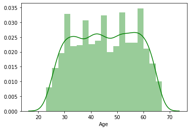

```python
#Histogram of Age
sns.distplot(df['Age'],color='green')
plt.show()
```

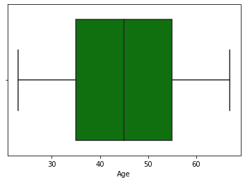

```python
# Check for outliers
sns.boxplot(df['Age'],color='green')
plt.show()
```

```python
#Check for skewness
df['Age'].skew()
```

```
-0.02934068151284029
```

- Age variable appears to be normally distributed with very low skewness
- The distribution in the age of the customers appears natural ranging from 23 to 67 years and has no outliers

#### b) Experience

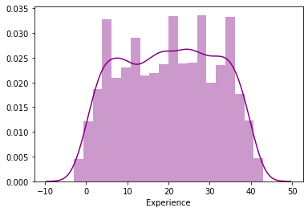

```python
#Histogram of Experience
sns.distplot(df['Experience'],color='purple')
plt.show()
```

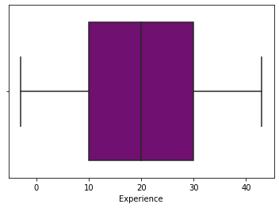

```python
# Check for outliers
sns.boxplot(df['Experience'],color='purple')
plt.show()
```

```python
#Check for skewness
df['Experience'].skew()
```

```
-0.026324688402384513
```

```python
#Check for negative values
df['Experience'][df['Experience']<0].count()
```

```
52
```

- There are 52 negative values in the Experience variable (-3,-2,-1) which have to be treated before modelling
- Experience variable appears to be normally distributed with very low skewness
- There are no outliers

#### c) Income

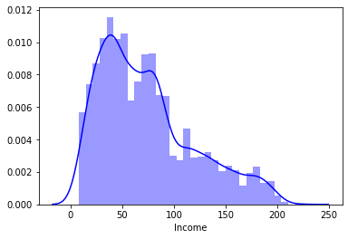

```python
#Histogram of Income
sns.distplot(df['Income'],color='blue')
plt.show()
```

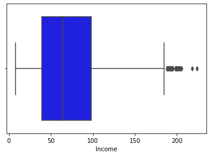

```python
#Check for outliers
sns.boxplot(df['Income'],color='blue')
plt.show()
```

```python
#Correlation between Income and CCAvg
df[['Income','CCAvg']].corr()
```

|  | Income | CCAvg |
| --- | --- | --- |
| Income | 1.000000 | 0.645984 |
| CCAvg | 0.645984 | 1.000000 |

```python
#Correlation between Income and Personal Loan
df[['Income','Personal Loan']].corr()
```

|  | Income | Personal Loan |
| --- | --- | --- |
| Income | 1.000000 | 0.502462 |
| Personal Loan | 0.502462 | 1.000000 |

```python
df[['Income','Personal Loan']].groupby('Personal Loan').mean()
```

| Personal Loan | Income |
| --- | --- |
| 0 | 66.237389 |
| 1 | 144.745833 |

- There are a few outliers in the Income variable
- The Income of customers is skewed which can also be noticed in the histogram and there are outliers present as a few customers have high annual income
- There is a moderately strong positive correlation between Income of Customers and opting for personal loans. The bank may consider design targeted marketing strategies based on income of customers
- Higher income groups tend to borrow personal loan

#### d) Family

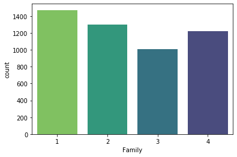

```python
#Check for the distribution of family members
sns.countplot(df['Family'],palette='viridis_r')
plt.show()
```

```python
df['Family'].value_counts()
```

```
1    1472
2    1296
4    1222
3    1010
Name: Family, dtype: int64
```

- More than half the customers have 2 people or less in their families
- The number of family members is distributed quite evenly with customers living alone being the highest

#### e) CCAvg

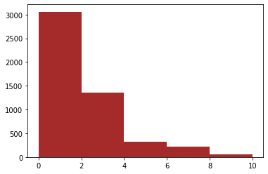

```python
#Distribution of average credit card spending
plt.hist(df['CCAvg'],bins=5,color='brown')
plt.show()
```

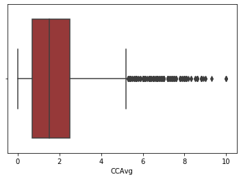

```python
# Check for outliers
sns.boxplot(df['CCAvg'],color='brown')
plt.show()
```

```python
#Check for skewness
df['CCAvg'].skew()
```

```
1.5984433366678663
```

- Avg CC spending variable is right skewed with a lot of outliers
- More than 60% of the customers have less than 4000USD as their average monthly CC spending

#### f) Education

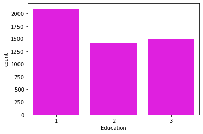

```python
#Distribution of Education
sns.countplot(df['Education'],color='magenta')
plt.show()
```

```python
df['Education'].value_counts()
```

```
1    2096
3    1501
2    1403
Name: Education, dtype: int64
```

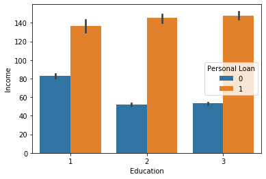

```python
#Income vs Education
sns.barplot(df['Education'],df['Income'],hue =df['Personal Loan'] )
plt.show()
```

#### g) Mortgage

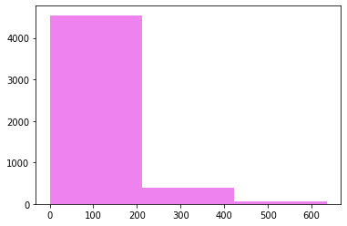

```python
#Distribution of Mortgage
plt.hist(df['Mortgage'],color='violet',bins=3)
plt.show()
```

```python
df['Mortgage'].value_counts().max()
```

```
3462
```

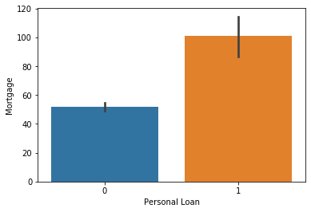

```python
sns.barplot(df['Personal Loan'],df['Mortgage'])
plt.show()
```

```python
df['Mortgage'].skew()
```

```
2.1040023191079444
```

```python
df[['Personal Loan','Mortgage']].groupby('Personal Loan').count()
```

| Personal Loan | Mortgage |
| --- | --- |
| 0 | 4520 |
| 1 | 480 |

- Mortgage data is highly skewed with about 70% of the customers having not mortgaged any property
- Customers who take personal loans tend to have mortgage accounts

#### h) Securities Account

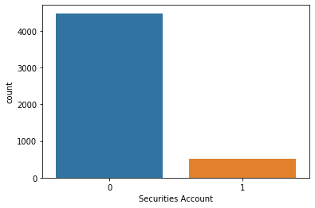

```python
#Distribution of Securities account
sns.countplot(df['Securities Account'])
plt.show()
```

```python
df['Securities Account'].value_counts()
```

```
0    4478
1     522
Name: Securities Account, dtype: int64
```

- About 90% of the customers have no securities account with the bank

#### i) CD Account

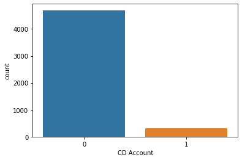

```python
#Distribution of CD account
sns.countplot(df['CD Account'])
plt.show()
```

```python
df['CD Account'].value_counts()
```

```
0    4698
1     302
Name: CD Account, dtype: int64
```

- Close to 94% of the customers do not have a CD account

#### j) Online

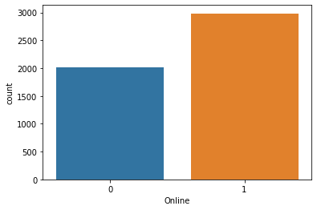

```python
#Distribution of CD account
sns.countplot(df['Online'])
plt.show()
```

```python
df['Online'].value_counts()
```

```
1    2984
0    2016
Name: Online, dtype: int64
```

- Close to 60% of the customers have registered for internet banking with the bank

#### k) CreditCard

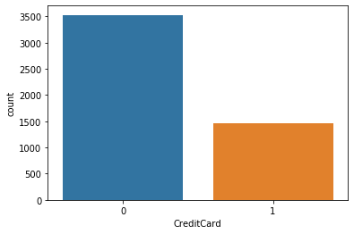

```python
#Distribution of CreditCard
sns.countplot(df['CreditCard'])
plt.show()
```

```python
df['CreditCard'].value_counts()
```

```
0    3530
1    1470
Name: CreditCard, dtype: int64
```

### 3) Distribution of the target variable

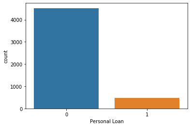

```python
#Distribution of Personal Loan
sns.countplot(df['Personal Loan'])
plt.show()
```

```python
df['Personal Loan'].value_counts()
```

```
0    4520
1     480
Name: Personal Loan, dtype: int64
```

```python
#Personal Loan against Income
df[['Personal Loan','Income']].groupby('Personal Loan').mean()
```

| Personal Loan | Income |
| --- | --- |
| 0 | 66.237389 |
| 1 | 144.745833 |

```python
#Personal Loan against Family
df[['Personal Loan','Family']].groupby('Family').sum()
```

| Family | Personal Loan |
| --- | --- |
| 1 | 107 |
| 2 | 106 |
| 3 | 133 |
| 4 | 134 |

```python
#Personal Loan against CCAvg
df[['Personal Loan','CCAvg']].groupby('Personal Loan').mean()
```

| Personal Loan | CCAvg |
| --- | --- |
| 0 | 1.729009 |
| 1 | 3.905354 |

```python
#Personal Loan against Securities Account
df[['Personal Loan','Securities Account']].groupby('Securities Account').sum()
```

| Securities Account | Personal Loan |
| --- | --- |
| 0 | 420 |
| 1 | 60 |

```python
#Personal Loan against CD Account
df[['Personal Loan','CD Account']].groupby('CD Account').sum()
```

| CD Account | Personal Loan |
| --- | --- |
| 0 | 340 |
| 1 | 140 |

```python
#Personal Loan against Online
df[['Personal Loan','Online']].groupby('Online').sum()
```

| Online | Personal Loan |
| --- | --- |
| 0 | 189 |
| 1 | 291 |

```python
#Personal Loan against Credit Card
df[['Personal Loan','CreditCard']].groupby('CreditCard').sum()
```

| CreditCard | Personal Loan |
| --- | --- |
| 0 | 337 |
| 1 | 143 |

- 90% of the customers have not availed personal loan from the bank
- The personal loan data is highly imbalanced
- Average monthly credit card spending of customers who avail loan is close to 4000USD
- Only one eighth of the customers who have a securities account availed personal loan

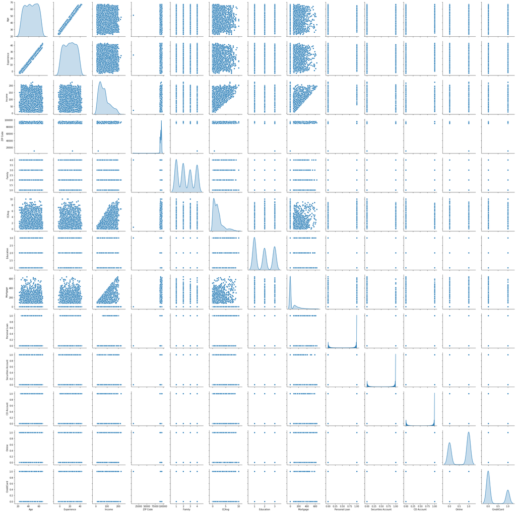

```python
#Pairplot to study the correlation between different variables
sns.pairplot(df.iloc[:,1:],diag_kind='kde')
plt.show()
```

#### Heat map to find the correlation between different attributes

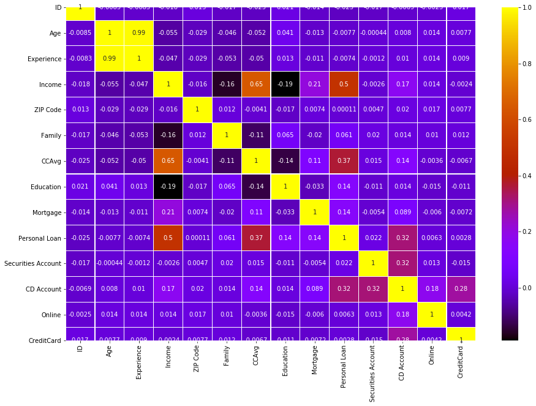

```python
plt.subplots(figsize=(15,10))
sns.heatmap(df.corr(),annot=True,linewidth=0.1,cmap='gnuplot')
plt.show()
```

Income of customers, their monthly average credit card spending and the holding of Certificate of Deposit accounts have moderately strong positive correlation with Personal Loan variable

#### Regression plot to find the relation between Age and Experience of customers

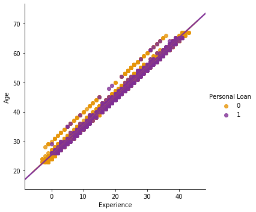

```python
#lmplot to find the correlation between Age and Experience variables
sns.lmplot('Experience','Age',df,hue='Personal Loan',palette='CMRmap_r')
plt.show()
```

The dataset has 52 records with variable 'Experience' showing negative values of (-1,-2,-3). Since work experience cannot be negative and it has a very strong positive correlation with 'Age' variable we can replace experience of customers with the average experience of customers of same age group.

```python
#Count of different Age groups for which Experience is negative
df[df['Experience'] < 0]['Age'].value_counts()
```

```
25    18
24    17
23    12
29     3
28     1
26     1
Name: Age, dtype: int64
```

As the values of customer ages where experience is small we can replace the negative values with mean of positive experience of same age

```python
negative_age = df[df['Experience']<0]['Age'].unique().tolist()
```

```python
indexes = df[df['Experience'] < 0].index.tolist()
```

```python
for i in indexes:
    for j in negative_age:
        df.loc[i,'Experience'] = df[(df['Age'] == j) & (df['Experience'] > 0)]['Experience'].mean()
```

```python
#Check if there are any negative values in 'Experience' column
df[df['Experience'] < 0].values.any()
```

```
False
```

No negative values in Experience column

```python
#Summary statistics of 'Experience' column after replacing negative values
df['Experience'].describe().T
```

```
count    5000.000000
mean       20.135743
std        11.413140
min         0.000000
25%        10.000000
50%        20.000000
75%        30.000000
max        43.000000
Name: Experience, dtype: float64
```

### 4) Splitting data for training and testing of our model

```python
#import the necessary function to split the data
from sklearn.model_selection import train_test_split

#Since columns 'ID' and 'ZIP Code' do not add value to our model, we can drop them

#Split the dataset into input variable X and target variable y
#Age variable as it is strongly correlated to Experience as dropping the former produces better result than the latter
X = df.drop(['ID','Personal Loan','ZIP Code','Age'],1)
y = df['Personal Loan']
```

```python
#Split the input and target variables into training and testing data
X_train,X_test,y_train,y_test = train_test_split(X,y,test_size=0.3,random_state=1)
```

```python
X_train.head()
```

|  | Experience | Income | Family | CCAvg | Education | Mortgage | Securities Account | CD Account | Online | CreditCard |
| --- | --- | --- | --- | --- | --- | --- | --- | --- | --- | --- |
| 1334 | 22.0 | 35 | 2 | 1.3 | 1 | 0 | 0 | 0 | 1 | 0 |
| 4768 | 14.0 | 39 | 1 | 2.0 | 2 | 0 | 0 | 0 | 1 | 0 |
| 65 | 35.0 | 131 | 1 | 3.8 | 1 | 0 | 0 | 0 | 1 | 1 |
| 177 | 3.0 | 65 | 4 | 1.8 | 2 | 244 | 0 | 0 | 0 | 0 |
| 4489 | 13.0 | 21 | 3 | 0.2 | 2 | 0 | 0 | 0 | 1 | 0 |

```python
y_train.head()
```

```
1334    0
4768    0
65      0
177     0
4489    0
Name: Personal Loan, dtype: int64
```

```python
# import different functions to scale data
from sklearn.preprocessing import MinMaxScaler,StandardScaler
from scipy.stats import zscore

#Scale training and testing data using min-max method
minmax = MinMaxScaler()
Xtrain_minmax = minmax.fit_transform(X_train)
Xtest_minmax = minmax.fit_transform(X_test)

X_train_z = X_train.apply(zscore)
X_test_z = X_test.apply(zscore)
```

### 5) Classification Models

### a) Logistic Regression

```python
#Import logistic regression function
from sklearn.linear_model import LogisticRegression

lr_model = LogisticRegression(solver='liblinear')

#fit the model
lr_model.fit(Xtrain_minmax,y_train)

#predict the target variable using test data
print(lr_model.predict(Xtest_minmax))
```

```
[0 0 0 ... 0 0 0]
```

```python
print('Training score for logistic regression:', lr_model.score(Xtrain_minmax,y_train))
print('Test score for logistic regression:', lr_model.score(Xtest_minmax,y_test))
```

```
Training score for logistic regression: 0.9505714285714286
Test score for logistic regression: 0.944
```

```python
#Import various accuracy metrics
from sklearn.metrics import classification_report, accuracy_score, f1_score, precision_score,recall_score,confusion_matrix

#Compute different metrices for the model
log_accuracy = round(accuracy_score(lr_model.predict(Xtest_minmax),y_test),2) #Accuracy score
log_f1 = round(f1_score(lr_model.predict(Xtest_minmax),y_test),2) #F1 score
log_precision = round(precision_score(lr_model.predict(Xtest_minmax),y_test),2) #Precision score
log_recall = round(recall_score(lr_model.predict(Xtest_minmax),y_test),2) #Recall score

print('Accuracy Score for logistic regression model testing data is:',log_accuracy)
print('F1 Score for logistic regression model testing data is:',log_f1)
print('Precision Score for logistic regression model testing data is:',log_precision)
print('Recall Score for logistic regression model testing data is:',log_recall)
```

```
Accuracy Score for logistic regression model testing data is: 0.94
F1 Score for logistic regression model testing data is: 0.68
Precision Score for logistic regression model testing data is: 0.6
Recall Score for logistic regression model testing data is: 0.78
```

```python
#Confusion Matrix
print(confusion_matrix(lr_model.predict(Xtest_minmax),y_test))
```

```
[[1326   59]
 [  25   90]]
```

```python
#Classification report for various metrics
print(classification_report(lr_model.predict(Xtest_minmax),y_test))
```

```
              precision    recall  f1-score   support

           0       0.98      0.96      0.97      1385
           1       0.60      0.78      0.68       115

    accuracy                           0.94      1500
   macro avg       0.79      0.87      0.83      1500
weighted avg       0.95      0.94      0.95      1500
```

### b) Naive Bayes

```python
#import required function from sklearn library
from sklearn.naive_bayes import GaussianNB

#Create a Naive Bayes Class
nb = GaussianNB()
```

```python
#fit the model
nb.fit(Xtrain_minmax,y_train.ravel())
```

```
GaussianNB(priors=None, var_smoothing=1e-09)
```

```python
#predict the output variable in test set
nb.predict(Xtest_minmax)
```

```
array([0, 0, 0, ..., 0, 0, 0], dtype=int64)
```

```python
print('Training score for Naive Bayes Model:', nb.score(Xtrain_minmax,y_train))
print('Test score for Naive Bayes Model:', nb.score(Xtest_minmax,y_test))
```

```
Training score for Naive Bayes Model: 0.8894285714285715
Test score for Naive Bayes Model: 0.876
```

```python
#Compute different metrices for the model
nb_accuracy = round(accuracy_score(nb.predict(Xtest_minmax),y_test),2) #Accuracy score
nb_f1 = round(f1_score(nb.predict(Xtest_minmax),y_test),2) #F1 score
nb_precision = round(precision_score(nb.predict(Xtest_minmax),y_test),2) #Precision score
nb_recall = round(recall_score(nb.predict(Xtest_minmax),y_test),2) #Recall score

print('Accuracy Score for Naive Bayes model testing data is:',nb_accuracy)
print('F1 Score for Naive Bayes model testing data is:',nb_f1)
print('Precision Score for Naive Bayes model testing data is:',nb_precision)
print('Recall Score for Naive Bayes model testing data is:',nb_recall)
```

```
Accuracy Score for Naive Bayes model testing data is: 0.88
F1 Score for Naive Bayes model testing data is: 0.5
Precision Score for Naive Bayes model testing data is: 0.62
Recall Score for Naive Bayes model testing data is: 0.42
```

```python
#Confusion Matrix
print(confusion_matrix(nb.predict(Xtest_minmax),y_test))
```

```
[[1221   56]
 [ 130   93]]
```

```python
#Classification report for various metrics
print(classification_report(nb.predict(Xtest_minmax),y_test))
```

```
              precision    recall  f1-score   support

           0       0.90      0.96      0.93      1277
           1       0.62      0.42      0.50       223

    accuracy                           0.88      1500
   macro avg       0.76      0.69      0.71      1500
weighted avg       0.86      0.88      0.87      1500
```

### c) K Nearest Neighbor

```python
#import KNN algorithm
from sklearn.neighbors import KNeighborsClassifier

#Create a class of KNN
neigh = KNeighborsClassifier(n_neighbors=3,weights='distance')

#fit the independent and dependent variable
neigh.fit(Xtrain_minmax,y_train)
```

```
KNeighborsClassifier(algorithm='auto', leaf_size=30, metric='minkowski',
                     metric_params=None, n_jobs=None, n_neighbors=3, p=2,
                     weights='distance')
```

```python
#Predict the target variable from testing data
neigh.predict(Xtest_minmax)
```

```
array([1, 0, 0, ..., 0, 0, 0], dtype=int64)
```

```python
print('Training score for KNN Model:', neigh.score(Xtrain_minmax,y_train))
print('Test score for KNN Model:', neigh.score(Xtest_minmax,y_test))
```

```
Training score for KNN Model: 1.0
Test score for KNN Model: 0.964
```

```python
#Compute different metrices for the model
knn_accuracy = round(accuracy_score(neigh.predict(Xtest_minmax),y_test),2) #Accuracy score
knn_f1 = round(f1_score(neigh.predict(Xtest_minmax),y_test),2) #F1 score
knn_precision = round(precision_score(neigh.predict(Xtest_minmax),y_test),2) #Precision score
knn_recall = round(recall_score(neigh.predict(Xtest_minmax),y_test),2) #Recall score

print('Accuracy Score for KNN model testing data is:',knn_accuracy)
print('F1 Score for KNN model testing data is:',knn_f1)
print('Precision Score for KNN model testing data is:',knn_precision)
print('Recall Score for KNN model testing data is:',knn_recall)
```

```
Accuracy Score for KNN model testing data is: 0.96
F1 Score for KNN model testing data is: 0.79
Precision Score for KNN model testing data is: 0.69
Recall Score for KNN model testing data is: 0.93
```

```python
#Confusion Matrix
print(confusion_matrix(neigh.predict(Xtest_minmax),y_test))
```

```
[[1343   46]
 [   8  103]]
```

```python
#Classification report for various metrics
print(classification_report(neigh.predict(Xtest_minmax),y_test))
```

```
              precision    recall  f1-score   support

           0       0.99      0.97      0.98      1389
           1       0.69      0.93      0.79       111

    accuracy                           0.96      1500
   macro avg       0.84      0.95      0.89      1500
weighted avg       0.97      0.96      0.97      1500
```

##### Choosing the best k value

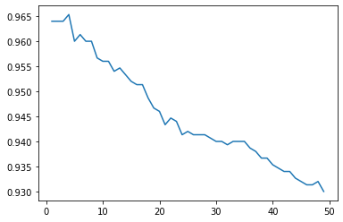

```python
scores = []
for k in range (1,50):
    neigh = KNeighborsClassifier(n_neighbors = k, weights = 'distance')
    neigh.fit(Xtrain_minmax,y_train)
    scores.append(neigh.score(Xtest_minmax,y_test))
plt.plot(range(1,50),scores)
plt.show()
```

### c) Support Vector Machine

```python
#import SVM algorithm
from sklearn import svm

#Create a class of SVM
#svm = svm.SVC(gamma=0.1,C=1)
svm = svm.SVC(gamma=0.06,C=17)


#fit the independent and dependent variable
svm.fit(Xtrain_minmax,y_train)
```

```
SVC(C=17, cache_size=200, class_weight=None, coef0=0.0,
    decision_function_shape='ovr', degree=3, gamma=0.06, kernel='rbf',
    max_iter=-1, probability=False, random_state=None, shrinking=True,
    tol=0.001, verbose=False)
```

```python
#Predict the target variable from testing data
svm.predict(Xtest_minmax)
```

```
array([0, 0, 0, ..., 0, 0, 0], dtype=int64)
```

```python
print('Training score for SVM Model:', svm.score(Xtrain_minmax,y_train))
print('Test score for SVM Model:', svm.score(Xtest_minmax,y_test))
```

```
Training score for SVM Model: 0.9737142857142858
Test score for SVM Model: 0.9726666666666667
```

```python
#Compute different metrices for the model
svm_accuracy = round(accuracy_score(svm.predict(Xtest_minmax),y_test),2) #Accuracy score
svm_f1 = round(f1_score(svm.predict(Xtest_minmax),y_test),2) #F1 score
svm_precision = round(precision_score(svm.predict(Xtest_minmax),y_test),2) #Precision score
svm_recall = round(recall_score(svm.predict(Xtest_minmax),y_test),2) #Recall score

print('Accuracy Score for SVM model testing data is:',svm_accuracy)
print('F1 Score for SVM model testing data is:',svm_f1)
print('Precision Score for SVM model testing data is:',svm_precision)
print('Recall Score for SVM model testing data is:',svm_recall)
```

```
Accuracy Score for SVM model testing data is: 0.97
F1 Score for SVM model testing data is: 0.85
Precision Score for SVM model testing data is: 0.79
Recall Score for SVM model testing data is: 0.92
```

```python
#Confusion Matrix
print(confusion_matrix(svm.predict(Xtest_minmax),y_test))
```

```
[[1341   31]
 [  10  118]]
```

```python
#Classification report for various metrics
print(classification_report(neigh.predict(Xtest_minmax),y_test))
```

```
              precision    recall  f1-score   support

           0       1.00      0.93      0.96      1452
           1       0.31      0.96      0.47        48

    accuracy                           0.93      1500
   macro avg       0.65      0.94      0.71      1500
weighted avg       0.98      0.93      0.95      1500
```

### 6) Confusion Matrices

###### a) Logistic Regression

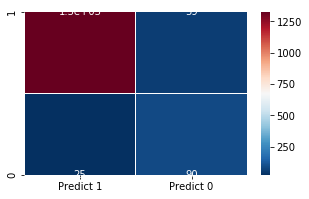

```
[[1326   59]
 [  25   90]]
```

```python
lrcm = confusion_matrix(lr_model.predict(Xtest_minmax),y_test)
df_lrcm = pd.DataFrame(lrcm,index = [i for i in ['1','0']],
                      columns = [i for i in ['Predict 1','Predict 0']])
plt.figure(figsize=(5,3))
sns.heatmap(df_lrcm,annot=True,linewidth=0.2,cmap='RdBu_r')
plt.show()
print(lrcm)
```

###### b) Naive Bayes

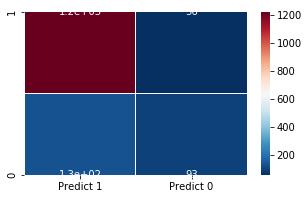

```
[[1221   56]
 [ 130   93]]
```

```python
nbcm = confusion_matrix(nb.predict(Xtest_minmax),y_test)
df_nbcm = pd.DataFrame(nbcm,index = [i for i in ['1','0']],
                      columns = [i for i in ['Predict 1','Predict 0']])
plt.figure(figsize=(5,3))
sns.heatmap(df_nbcm,annot=True,linewidth=0.2,cmap='RdBu_r')
plt.show()
print(nbcm)
```

###### c) K Nearest Neighbor

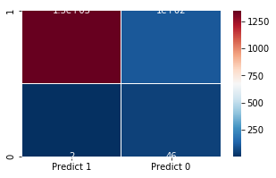

```
[[1349  103]
 [   2   46]]
```

```python
knncm = confusion_matrix(neigh.predict(Xtest_minmax),y_test)
df_knncm = pd.DataFrame(knncm,index = [i for i in ['1','0']],
                      columns = [i for i in ['Predict 1','Predict 0']])
plt.figure(figsize=(5,3))
sns.heatmap(df_knncm,annot=True,linewidth=0.2,cmap='RdBu_r')
plt.show()
print(knncm)
```

###### d) Support Vector Machine

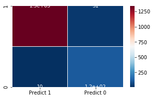

```
[[1341   31]
 [  10  118]]
```

```python
svmcm = confusion_matrix(svm.predict(Xtest_minmax),y_test)
df_svmcm = pd.DataFrame(svmcm,index = [i for i in ['1','0']],
                      columns = [i for i in ['Predict 1','Predict 0']])
plt.figure(figsize=(5,3))
sns.heatmap(df_svmcm,annot=True,linewidth=0.2,cmap='RdBu_r')
plt.show()
print(svmcm)
```

```python
#Tabulate the different metrics of all four models
model_df=pd.DataFrame(data=[[log_accuracy,nb_accuracy,knn_accuracy,svm_accuracy],[log_f1,nb_f1,knn_f1,svm_f1],[log_precision,nb_precision,knn_precision,svm_precision],[log_recall,nb_recall,knn_recall,svm_recall]],index=['Accuracy','F1_Score','Precision','Recall'],columns=['Logistic Regression','Naive Bayes','K Nearest Neighbor','Support Vector Machine'])
print('The different metrices for all the models are as below:')
model_df
```

```
The different metrices for all the models are as below:
```

|  | Logistic Regression | Naive Bayes | K Nearest Neighbor | Support Vector Machine |
| --- | --- | --- | --- | --- |
| Accuracy | 0.94 | 0.88 | 0.96 | 0.97 |
| F1_Score | 0.68 | 0.50 | 0.79 | 0.85 |
| Precision | 0.60 | 0.62 | 0.69 | 0.79 |
| Recall | 0.78 | 0.42 | 0.93 | 0.92 |